# Regression versus State-Space

2 Mar 2021

## Fixed & random effects

Let’s go back to Mark’s [lecture on DFA](https://atsa-es.github.io/atsa/Lectures/Week%204/lec_08_intro_to_DFA.html#25)

\[ y_t = \underbrace{\alpha + \beta x_t}_{\text{fixed}} + ~ \underbrace{f_t + e_t}_{\text{random}} \]

Regression (linear or non-linear) with correlated errors gets your the fixed effects while properly taking into account the correlated random effects.

State-space model allows you to model the \(f_t\).

## Things to think about

\[ y_t = \underbrace{\alpha + \beta x_t}_{\text{fixed}} + ~ \underbrace{f_t + e_t}_{\text{random}} \]

- What if your want \(f_t\), the hidden random walk
- What if you want \(E[\alpha + \beta x_t + f_t]\)
- What if you want the \(E[y_t | y_{1:t-1}]\)
- What if we want to forecast \(y_t\)?

## Let’s simulate some data

\[ \begin{gathered} x_t = t \\ f_t = \phi f_{t-1} + w_t, \, w_t \sim N(0,1)\\ y_t = \beta x_t + f_t + v_t, \, v_t \sim N(0,\sqrt{0.2}) \end{gathered} \]

## Simulated data

```r
set.seed(123)
N <- 100; h <- 100; x <- 1:N
sim1 <- sim.data(N, h=h, phi=0.8)
sim2 <- sim.data(N, h=h, phi=1)
```

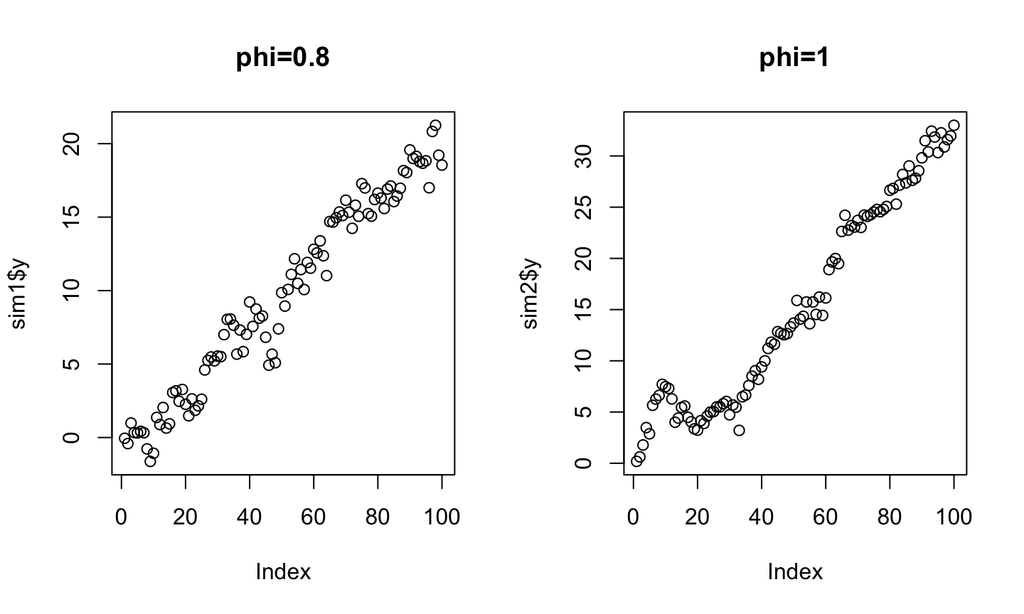

## Fit with arima(y, xreg=x)

Fits a linear regression with ARMA errors.

```r
library(forecast)
fit <- auto.arima(sim1$y, xreg=x)
fr1 <- forecast(fit, xreg=(N+1):(N+h))
fit <- auto.arima(sim2$y, xreg=x)
fr2 <- forecast(fit, xreg=(N+1):(N+h))
```

## Plot forecasts versus true

I created simulations from the true process to get truth.

Plot shows prediction intervals (future y). Red lines are true 80% intervals.

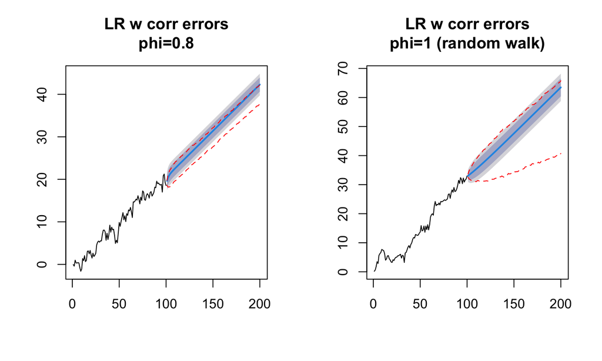

## Fitted

You need to be careful to think about what you mean by `fitted()`

- `gls(y~x)` and similar would return \(E[\alpha+\beta x_t]\)
- `arima(y, xreg=x)` returns \(E[\alpha+\beta x_t + e_t|y_{1:t-1}]\)
- state-space model would get you \(E[\alpha+\beta x_t + f_t|y_{1:N}]\)

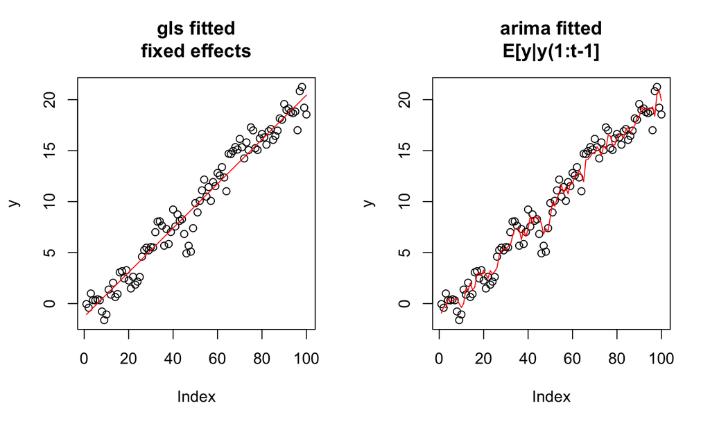

## Regression w ARMA errors vs ARMAX

These are different models.

Regression w AR1 errors

\[ \begin{gathered} e_t = \phi e_{t-1} + w_t \\ y_t = \alpha + \beta x_t + e_t \end{gathered} \]

ARMAX: In this case, AR(1)-X

\[ y_t = \phi y_{t-1} + \alpha + \beta x_t + w_t \]